# Cyclistic bike-share

Silvester Cheptumo

2023-12-06

```r
suppressWarnings({
library(dplyr)
library(tidyverse)
library(ggplot2)
library(lubridate)
library(forcats)
})
divvy4 <- read.csv("divvy-202004-tripdata.csv")
divvy5 <- read.csv("divvy-202005-tripdata.csv")
divvy6 <- read.csv("divvy-202006-tripdata.csv")
divvy7 <- read.csv("divvy-202007-tripdata.csv")
divvy8 <- read.csv("divvy-202008-tripdata.csv")
divvy9 <- read.csv("divvy-202009-tripdata.csv")
divvy10 <- read.csv("divvy-202010-tripdata.csv")
divvy11 <- read.csv("divvy-202011-tripdata.csv")
divvy12 <- read.csv("divvy-202012-tripdata.csv")
divvy01 <- read.csv("divvy-202101-tripdata.csv")
divvy02 <- read.csv("divvy-202102-tripdata.csv")
divvy03 <-  read.csv("divvy-202103-tripdata.csv")
```

```r
divvy_merged <- rbind(divvy4,divvy5,divvy6,divvy7,divvy8,divvy9,divvy10, divvy11, divvy12, divvy01, divvy02, divvy03)
str(divvy_merged)
```

```
## 'data.frame':    3489748 obs. of  13 variables:
##  $ ride_id           : chr  "A847FADBBC638E45" "5405B80E996FF60D" "5DD24A79A4E006F4" "2A59BBDF5CDBA725" ...
##  $ rideable_type     : chr  "docked_bike" "docked_bike" "docked_bike" "docked_bike" ...
##  $ started_at        : chr  "2020-04-26 17:45:14" "2020-04-17 17:08:54" "2020-04-01 17:54:13" "2020-04-07 12:50:19" ...
##  $ ended_at          : chr  "2020-04-26 18:12:03" "2020-04-17 17:17:03" "2020-04-01 18:08:36" "2020-04-07 13:02:31" ...
##  $ start_station_name: chr  "Eckhart Park" "Drake Ave & Fullerton Ave" "McClurg Ct & Erie St" "California Ave & Division St" ...
##  $ start_station_id  : chr  "86" "503" "142" "216" ...
##  $ end_station_name  : chr  "Lincoln Ave & Diversey Pkwy" "Kosciuszko Park" "Indiana Ave & Roosevelt Rd" "Wood St & Augusta Blvd" ...
##  $ end_station_id    : chr  "152" "499" "255" "657" ...
##  $ start_lat         : num  41.9 41.9 41.9 41.9 41.9 ...
##  $ start_lng         : num  -87.7 -87.7 -87.6 -87.7 -87.6 ...
##  $ end_lat           : num  41.9 41.9 41.9 41.9 42 ...
##  $ end_lng           : num  -87.7 -87.7 -87.6 -87.7 -87.7 ...
##  $ member_casual     : chr  "member" "member" "member" "member" ...
```

The resulting dataset has 13 columns and more than 3 million rows. Of these columns, we will, only be needing a few of them.

```r
#selecting the columns to use
divvy_df <- divvy_merged %>%
  select(rideable_type, start_station_name, end_station_name, member_casual, started_at, ended_at)
```

check for missing values

```r
colSums(is.na(divvy_df))
```

```
##      rideable_type start_station_name   end_station_name      member_casual
##                  0                  0                  0                  0
##         started_at           ended_at
##                  0                  0
```

Since there are no missing values, we proceed to create new columns from the started_at and ended_at columns

```r
#converting dates from character to date format and finding the cycling duration
divvy_df$started_at <- ymd_hms(divvy_df$started_at) #ymd_hms is a function in lubridate library
divvy_df$ended_at <- ymd_hms(divvy_df$ended_at)
```

Extract cycling_time in minutes

```r
divvy_df <- divvy_df %>%
  mutate(cycling_time = ended_at - started_at) %>%
  mutate(cycling_time_minutes = as.numeric(round(cycling_time/60, digits=2)))
```

Extract hours from start time

```r
divvy_df <- divvy_df %>%
  mutate(start_hour = format(started_at, "%H"))
str(divvy_df)
```

```
## 'data.frame':    3489748 obs. of  9 variables:
##  $ rideable_type       : chr  "docked_bike" "docked_bike" "docked_bike" "docked_bike" ...
##  $ start_station_name  : chr  "Eckhart Park" "Drake Ave & Fullerton Ave" "McClurg Ct & Erie St" "California Ave & Division St" ...
##  $ end_station_name    : chr  "Lincoln Ave & Diversey Pkwy" "Kosciuszko Park" "Indiana Ave & Roosevelt Rd" "Wood St & Augusta Blvd" ...
##  $ member_casual       : chr  "member" "member" "member" "member" ...
##  $ started_at          : POSIXct, format: "2020-04-26 17:45:14" "2020-04-17 17:08:54" ...
##  $ ended_at            : POSIXct, format: "2020-04-26 18:12:03" "2020-04-17 17:17:03" ...
##  $ cycling_time        : 'difftime' num  1609 489 863 732 ...
##   ..- attr(*, "units")= chr "secs"
##  $ cycling_time_minutes: num  26.82 8.15 14.38 12.2 52.92 ...
##  $ start_hour          : chr  "17" "17" "17" "12" ...
```

Extracting month-year from start time

```r
# Extract the month and year from the start time
divvy_df <- divvy_df %>%
  mutate(Month_year = format(started_at, "%Y-%m"))
```

```r
str(divvy_df)
```

```
## 'data.frame':    3489748 obs. of  10 variables:
##  $ rideable_type       : chr  "docked_bike" "docked_bike" "docked_bike" "docked_bike" ...
##  $ start_station_name  : chr  "Eckhart Park" "Drake Ave & Fullerton Ave" "McClurg Ct & Erie St" "California Ave & Division St" ...
##  $ end_station_name    : chr  "Lincoln Ave & Diversey Pkwy" "Kosciuszko Park" "Indiana Ave & Roosevelt Rd" "Wood St & Augusta Blvd" ...
##  $ member_casual       : chr  "member" "member" "member" "member" ...
##  $ started_at          : POSIXct, format: "2020-04-26 17:45:14" "2020-04-17 17:08:54" ...
##  $ ended_at            : POSIXct, format: "2020-04-26 18:12:03" "2020-04-17 17:17:03" ...
##  $ cycling_time        : 'difftime' num  1609 489 863 732 ...
##   ..- attr(*, "units")= chr "secs"
##  $ cycling_time_minutes: num  26.82 8.15 14.38 12.2 52.92 ...
##  $ start_hour          : chr  "17" "17" "17" "12" ...
##  $ Month_year          : chr  "2020-04" "2020-04" "2020-04" "2020-04" ...
```

### Exploratory Data Analysis

```
## Defaulting to continuous.
```

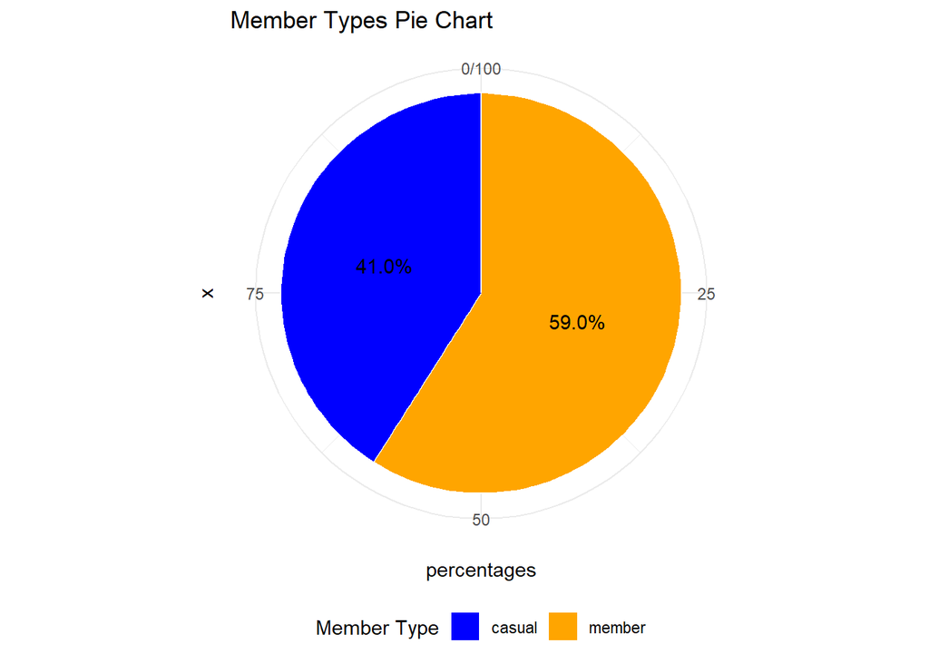

```r
member_type <- table(divvy_df$member_casual)
percentages <- prop.table(member_type) * 100

# Convert data to a data frame
pie_data <- data.frame(member_type = names(member_type), percentage = percentages)

# Create a pie chart using ggplot2
ggplot(pie_data, aes(x = "", y = percentages, fill = member_type)) +
  geom_bar(stat = "identity", width = 1, color = "white") +
  coord_polar("y") +
  labs(title = "Member Types Pie Chart", fill = "Member Type") +
  theme_minimal() +
  theme(legend.position = "bottom") +
  geom_text(aes(label = sprintf("%.1f%%", percentages)), position = position_stack(vjust = 0.5)) +
  scale_fill_manual(values = c("blue", "orange"))
```

The pie chart above shows that casuals constitute 41% while members constitute 59%.

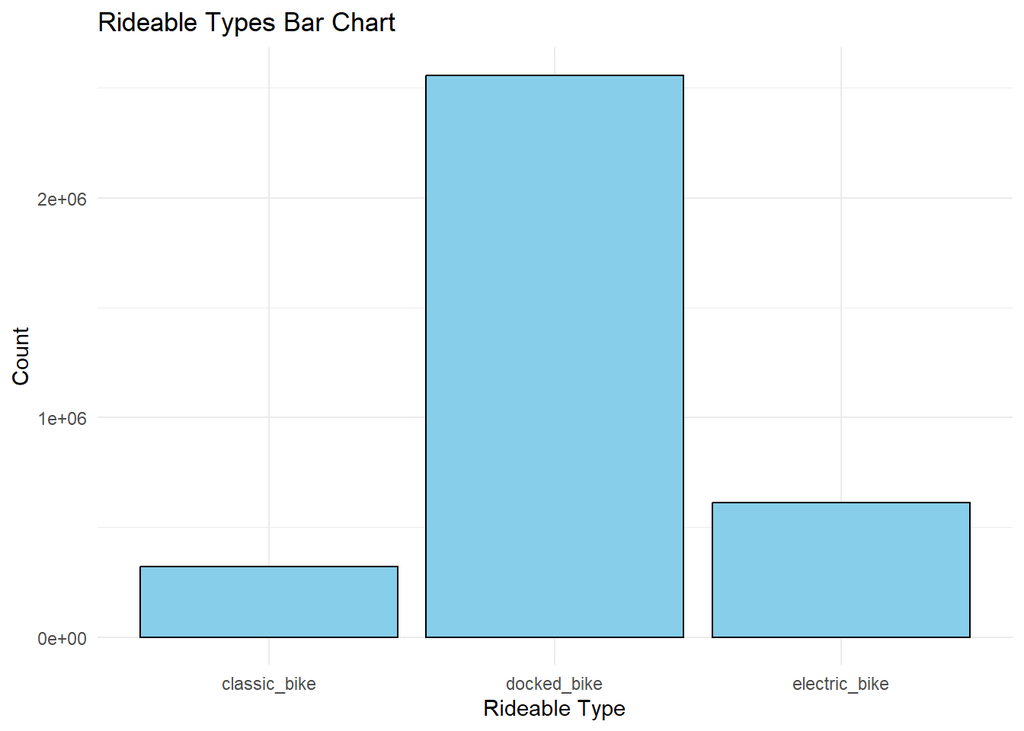

```r
rideable_counts <- table(divvy_df$rideable_type)
#creating a bar chart from ggplot for the rideable_types
ggplot(data = data.frame(rideable_type = names(rideable_counts), count = as.numeric(rideable_counts)),
       aes(x = rideable_type, y = count)) +
  geom_bar(stat = "identity", fill = "skyblue", color = "black") +
  labs(title = "Rideable Types Bar Chart", x = "Rideable Type", y = "Count") +
  theme_minimal()
```

The barchart shows that the docked_bikes, electric_bikes and classic_bikes are preferred in that order.

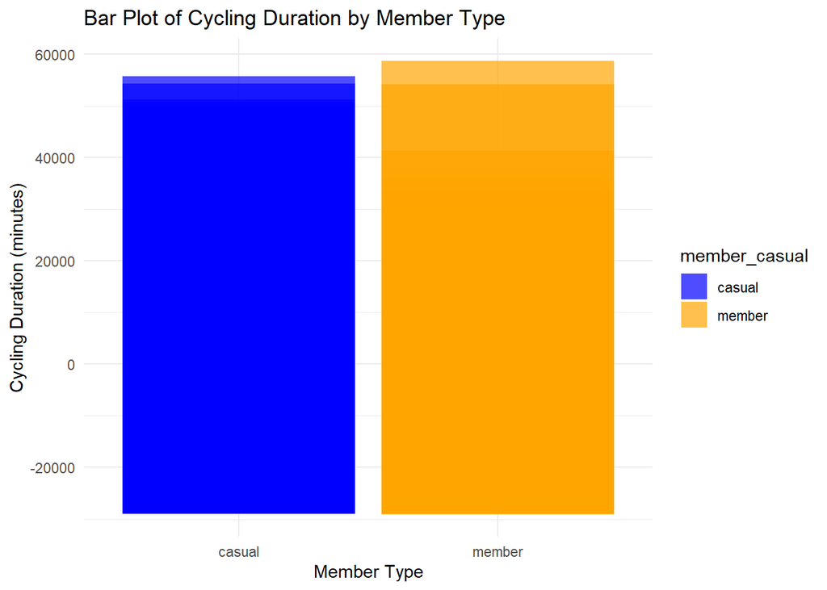

```r
ggplot(data = divvy_df, aes(x = member_casual, y = cycling_time_minutes, fill = member_casual)) +
  geom_bar(stat = "identity", position = "dodge", alpha = 0.7) +
  labs(title = "Bar Plot of Cycling Duration by Member Type",
       x = "Member Type", y = "Cycling Duration (minutes)") +
  theme_minimal() +
  scale_fill_manual(values = c("blue", "orange"))
```

Let us now look at the peak hours that the member and casuals use the bikes

```r
# Group by hour and ride category, count the number of rides
peak_hours <- divvy_df %>%
  group_by(start_hour, member_casual) %>%
  summarize(ride_count = n())
```

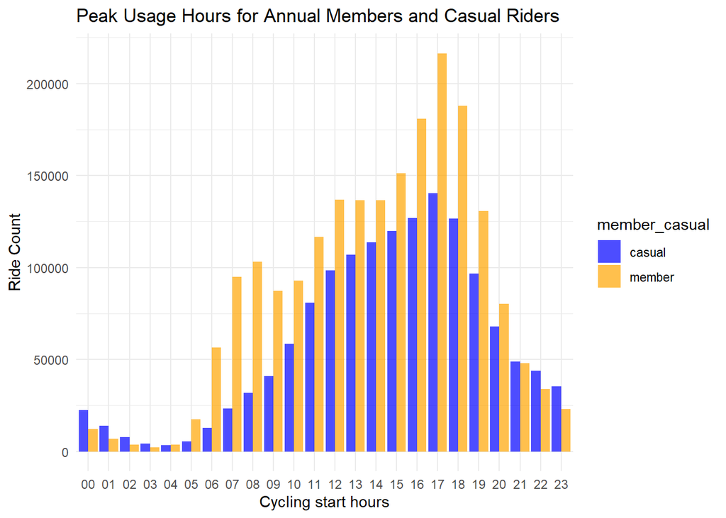

```r
# Create a plot to visualize the peak usage hours for each group
ggplot(peak_hours, aes(x = start_hour, y = ride_count, fill = member_casual)) +
  geom_bar(stat = "identity", position = "dodge", alpha = 0.7) +
  labs(title = "Peak Usage Hours for Annual Members and Casual Riders",
       x = "Cycling start hours", y = "Ride Count") +
  theme_minimal() +
  scale_fill_manual(values = c("blue", "orange"))
```

### seasonality/trends of the rides

```r
# Group by month_year, ride category, and count the number of rides
monthly_trends <- divvy_df %>%
  group_by(Month_year, member_casual) %>%
  summarize(ride_count = n())
```

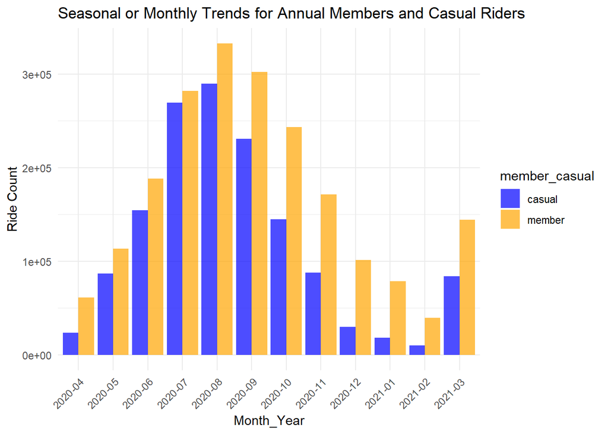

```r
# Create a plot to visualize the seasonal or monthly trends for each group
ggplot(monthly_trends, aes(x = Month_year, y = ride_count, fill = member_casual)) +
  geom_bar(stat = "identity", position = "dodge", alpha = 0.7) +
  labs(title = "Seasonal or Monthly Trends for Annual Members and Casual Riders",
       x = "Month_Year", y = "Ride Count") +
  theme_minimal() +
  scale_x_discrete(labels = scales::date_format("%Y-%m")) +
  scale_fill_manual(values = c("blue", "orange"))+
  theme(axis.text.x = element_text(angle = 45, hjust = 1))
```

Popular start stations by membership type

```r
# Group by start and end stations, count the number of rides for each group
popular_start_routes <- divvy_df %>%
  filter(!is.na(start_station_name) & start_station_name != "") %>% # remove rows with empty start_station
  group_by(member_casual, start_station_name) %>%
  summarize(route_count = n()) %>%
  arrange(member_casual, desc(route_count)) %>%
  top_n(5, wt = route_count)
popular_start_routes
```

```
## # A tibble: 10 × 3
## # Groups:   member_casual [2]
##    member_casual start_station_name        route_count
##    <chr>         <chr>                           <int>
##  1 casual        Streeter Dr & Grand Ave         26263
##  2 casual        Lake Shore Dr & Monroe St       20742
##  3 casual        Millennium Park                 19564
##  4 casual        Theater on the Lake             15095
##  5 casual        Michigan Ave & Oak St           13750
##  6 member        Clark St & Elm St               20397
##  7 member        Broadway & Barry Ave            15814
##  8 member        Dearborn St & Erie St           15465
##  9 member        St. Clair St & Erie St          15390
## 10 member        Wells St & Concord Ln           15147
```

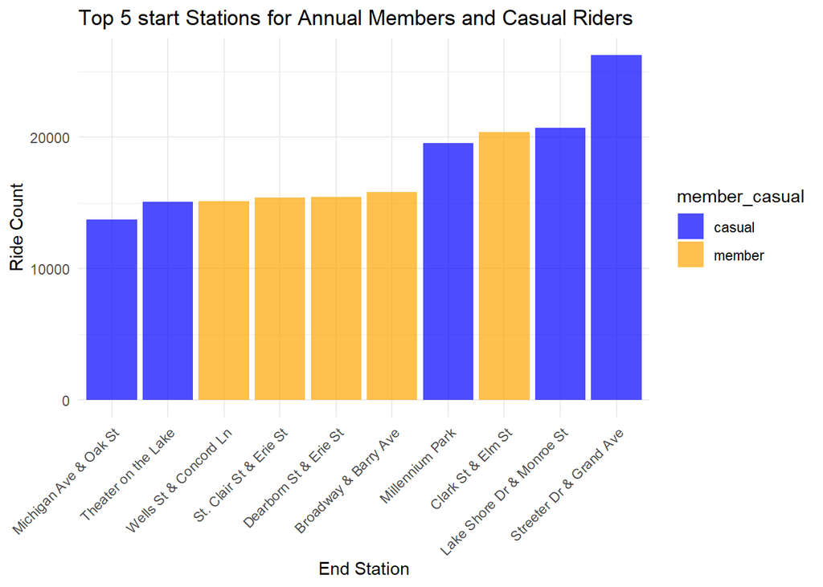

```r
# Create a bar plot to visualize the top 5 start stations for each group
ggplot(popular_start_routes, aes(x = fct_reorder(start_station_name, route_count), y = route_count, fill = member_casual)) +
  geom_col(position = "dodge", alpha = 0.7) +
  labs(title = "Top 5 start Stations for Annual Members and Casual Riders",
       x = "End Station", y = "Ride Count") +
  theme_minimal() +
  scale_fill_manual(values = c("blue", "orange")) +
  theme(axis.text.x = element_text(angle = 45, hjust = 1))  # Rotate x-axis labels for better readability
```

The popular start stations for casuals is Streeter Dr & Grand Ave while the popular start station for member is Clark St & Elm St.

popular end stations

```r
# Group by end stations, count the number of rides for each group
popular_end_routes <- divvy_df %>%
  filter(!is.na(end_station_name) & end_station_name != "") %>%  # remove rows with empty end station
  group_by(member_casual, end_station_name) %>%
  summarize(route_count = n()) %>%
  arrange(member_casual, desc(route_count)) %>%
   top_n(5, wt = route_count)
popular_end_routes
```

```
## # A tibble: 10 × 3
## # Groups:   member_casual [2]
##    member_casual end_station_name           route_count
##    <chr>         <chr>                            <int>
##  1 casual        Streeter Dr & Grand Ave          28471
##  2 casual        Millennium Park                  20258
##  3 casual        Lake Shore Dr & Monroe St        20172
##  4 casual        Theater on the Lake              16850
##  5 casual        Lake Shore Dr & North Blvd       14321
##  6 member        Clark St & Elm St                20849
##  7 member        St. Clair St & Erie St           16540
##  8 member        Broadway & Barry Ave             16033
##  9 member        Dearborn St & Erie St            16013
## 10 member        Wells St & Concord Ln            15537
```

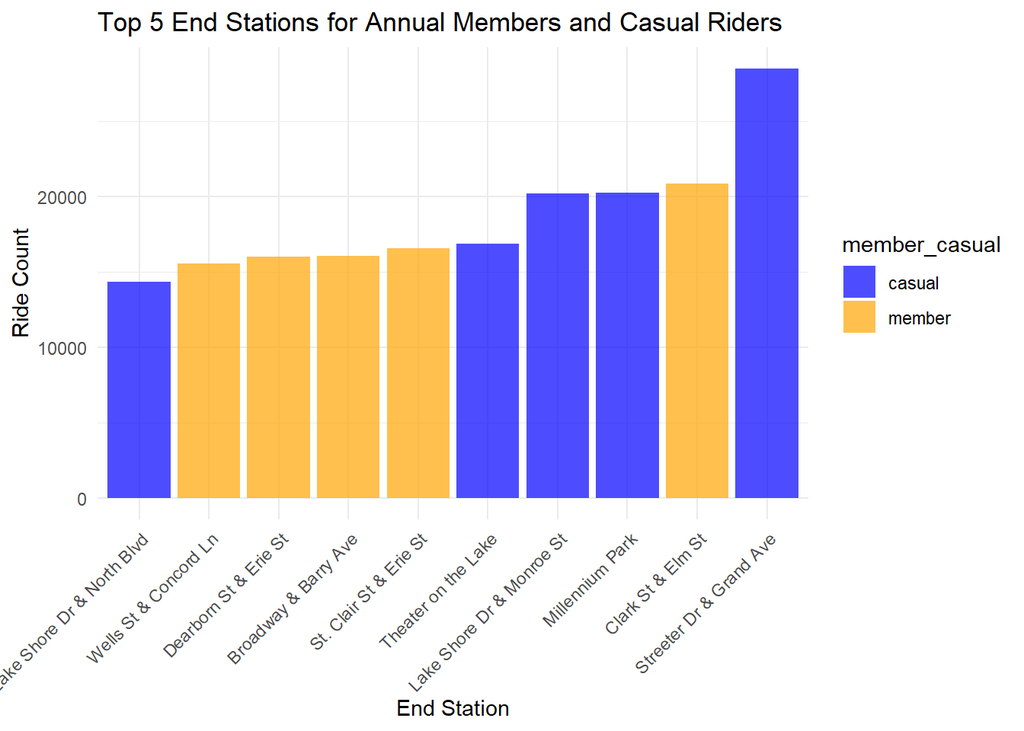

```r
# Create a bar plot to visualize the top 5 end stations for each group
ggplot(popular_end_routes, aes(x = fct_reorder(end_station_name, route_count), y = route_count, fill = member_casual)) +
  geom_col(position = "dodge", alpha = 0.7) +
  labs(title = "Top 5 End Stations for Annual Members and Casual Riders",
       x = "End Station", y = "Ride Count") +
  theme_minimal() +
  scale_fill_manual(values = c("blue", "orange")) +
  theme(axis.text.x = element_text(angle = 45, hjust = 1))  # Rotate x-axis labels for better readability
```

The bar plot shows that the top end station for casuals is Streeter Dr & Grand Ave while for members, their popular end station is Clark St & Elm St.

Checking how the various rideable types are popular among the customers

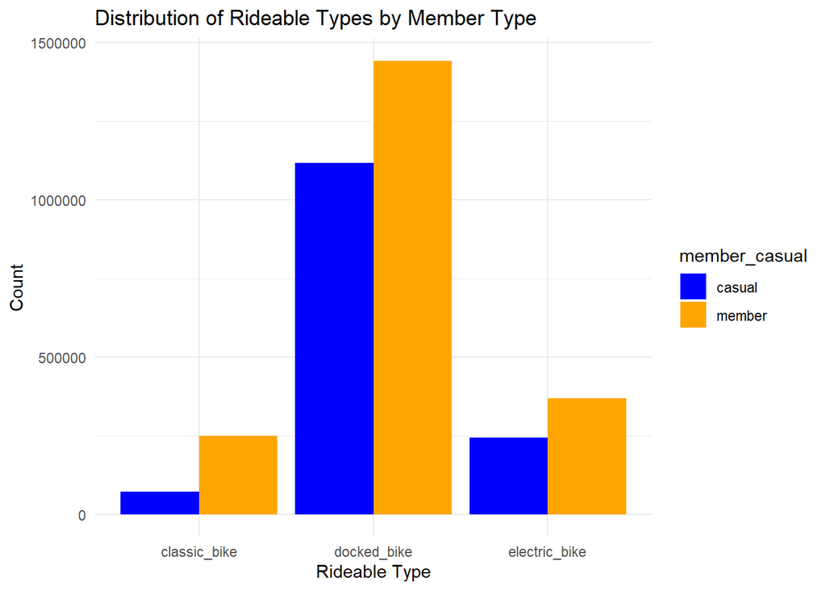

```r
# Create a table of rideable types by member_casual
rideable_by_member <- as.data.frame(table(divvy_df$rideable_type, divvy_df$member_casual))

# Rename the columns to 'rideable_type', 'member_casual', and 'count'
colnames(rideable_by_member) <- c('rideable_type', 'member_casual', 'count')

# Create a bar plot
ggplot(rideable_by_member, aes(x = rideable_type, y = count, fill = member_casual)) +
  geom_bar(stat = "identity", position = "dodge") +
  labs(title = "Distribution of Rideable Types by Member Type",
       x = "Rideable Type", y = "Count") +
  theme_minimal() +
  scale_fill_manual(values = c("blue", "orange"))
```

The bar chart above shows that docked_bike is the most popular bike among both membership types.